# Part 3 — Joining structural and annotation descriptions

Everything in Part 1 describes the annotation data on its own terms; everything in Part 2 describes the graph on its own terms. Neither is a baseline the other is checked against. This section places them side by side and reads the relationship, which is where the actual analytical content of this project lives.

```
Loaded df from disk: 369 rows
```

```
Loaded node_table from disk: 12697 rows
```

```
structural_df: 12697 rows. is_ghost values: FALSE (class: logical )
```

```
Joined cluster_table_annotated: 12697 rows
```

```
Rows with a matching annotation: 369
```

## Cluster structure vs. topics, methods, and sources of evidence

`community_gn` (Girvan-Newman, fragmentation-onset cut) is checked here against the topics, methods, and sources of evidence coded in Part 1, for both versions of the graph. Annotated uses the cut of the Annotated run and Annotated, seed filtered uses the cut of the seed-filtered run. The comparison is restricted to works with a matching annotation (F1-only; see the join above), which is 369 works in Annotated and 369 in Annotated, seed filtered. Louvain and Leiden cluster assignments also exist from Part 2 but are not used in this section.

Coverage is thin relative to the graph as a whole: in Annotated, 369 annotated works out of 12697 nodes, and within any single cluster that annotated count is often a small fraction of the cluster’s real size (the heatmaps below show the clusters tied for the 20 most annotated works, 33 in Annotated and 47 in Annotated, seed filtered, and no cluster holds more than 4 annotated works out of a much larger true membership). A prior exploratory pass on an earlier GN cut of this same corpus found 7-13 annotated nodes per cluster typical, out of hundreds of members, and treated agreement between structure and annotation as directionally suggestive rather than comprehensively verified for that reason. The same caution applies here: what follows can show that structure and coding line up somewhere, but cannot rule out that the uncoded majority of any cluster tells a different story.

The coded columns are wide, one column per topic/method/source category, valued `"Primary"`, `"Secondary"`, or blank. Primary and secondary are merged throughout what follows: a work counts as coded with a category at either level, matching the method used in a prior exploratory pass on an earlier GN cut of this corpus. A work can carry more than one topic, method, or source, so per-cluster percentages below do not sum to 100%; each cell shows the raw count behind its percentage for transparency.

**How to read the enrichment heatmaps below.** Raw coverage (what fraction of a cluster’s annotated works carry a given category) is misleading on its own: some categories are common across the whole corpus regardless of cluster — “Spatial analysis” as a method, or “Environment” as a topic, show up in most clusters simply because most works in this corpus use them, not because any one cluster is distinctively characterized by them. To separate genuine distinctiveness from corpus-wide popularity, each heatmap cell instead shows **enrichment**: a cluster’s coverage of a category divided by that category’s rate across the whole annotated corpus. A value of 1x means the cluster carries the category at exactly the corpus average; 2x means twice the corpus rate; 0.5x means half. White is 1x (baseline); blue is above baseline (the category is over-represented in that cluster, a real distinguishing signal); red is below baseline (under-represented). For example, if “Palaeoenvironment reconstruction” is coded in 23% of the whole corpus but 100% of a given cluster’s annotated works, that cell shows roughly 4.4x — a real signal that environmental method is disproportionately concentrated there, not just present because it’s common everywhere.

### By topic

**Girvan-Newman clusters by topic.** A threshold of 3+ annotated works lets through only a small share of the clusters in this corpus (see the counts below), so it does not give a workable set. Shown here instead, in the heatmap below: the clusters tied for the 20 most annotated works (33 in Annotated and 47 in Annotated, seed filtered, because many clusters tie at two annotated works). This is a readability choice, not a derived breakpoint.

At this cut, Annotated has 794 clusters, 5 of which pass a 3+ annotated-works threshold, and its largest cluster is 30 members larger than the second-largest. Annotated, seed filtered has 595 clusters, 5 of which pass the threshold, and its largest cluster is 17 members larger than the second-largest.

Coverage varies a lot by cluster (annotation is thin relative to true cluster size, per the caveat above), so each row label shows how many annotated works its percentages are based on, out of the cluster’s true total size.

**Annotated**

Works with a cluster assignment and any topic coded: 369

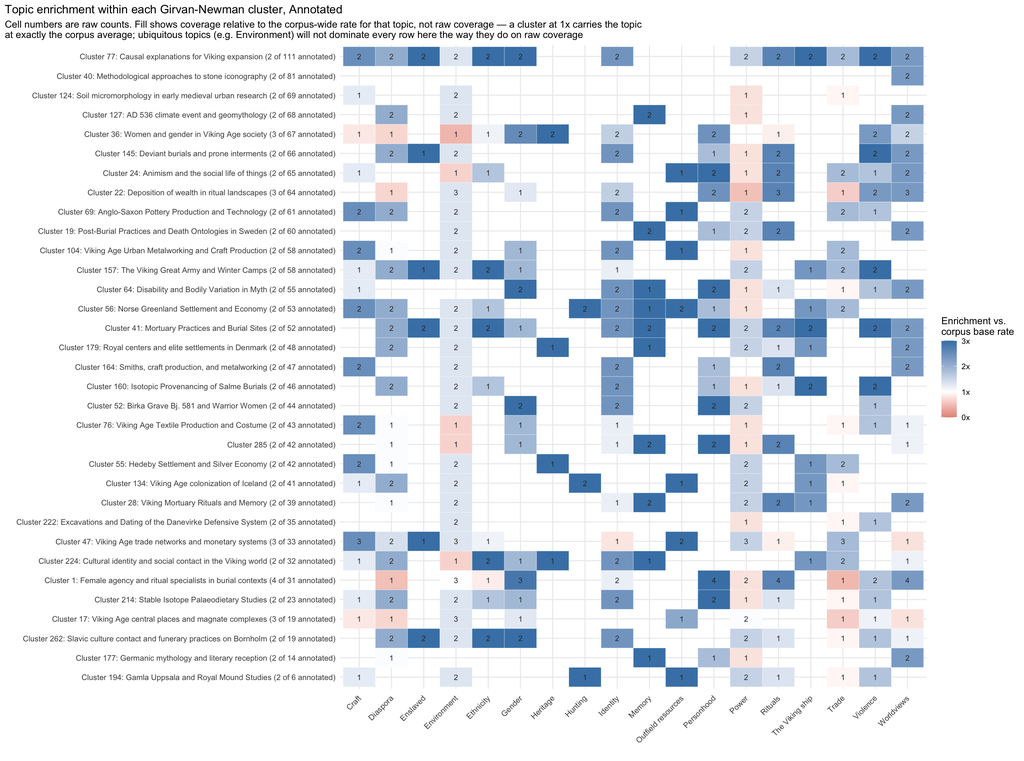

**Annotated, seed filtered**

Works with a cluster assignment and any topic coded: 369

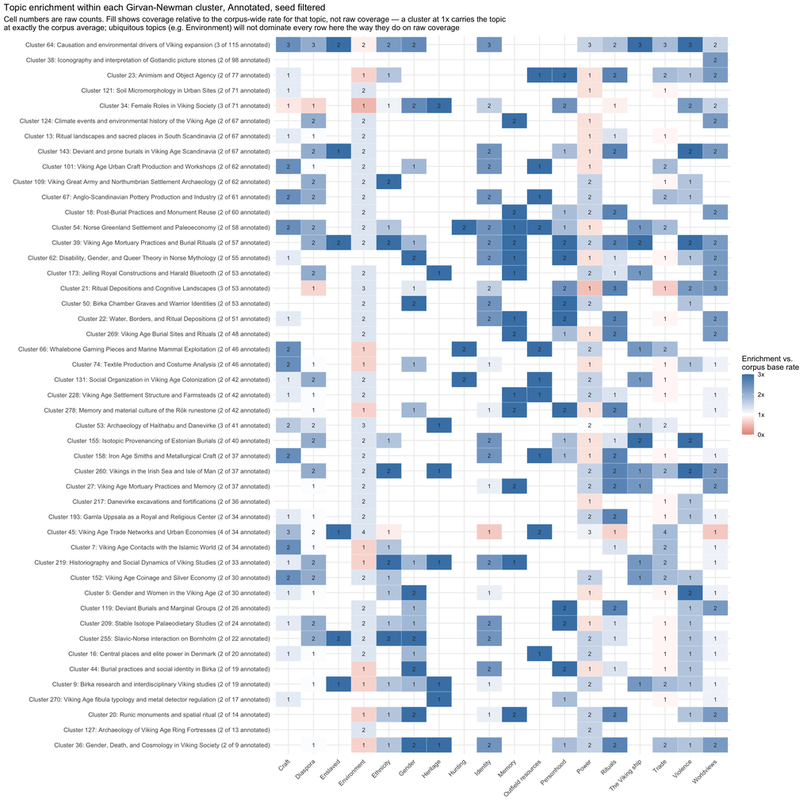

### By method

Same approach as the topic comparison above, applied to method.

**Annotated**

Works with a cluster assignment and any method coded: 368

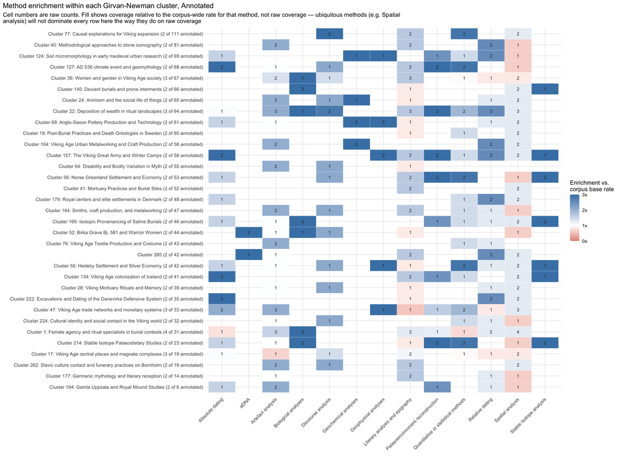

**Annotated, seed filtered**

Works with a cluster assignment and any method coded: 368

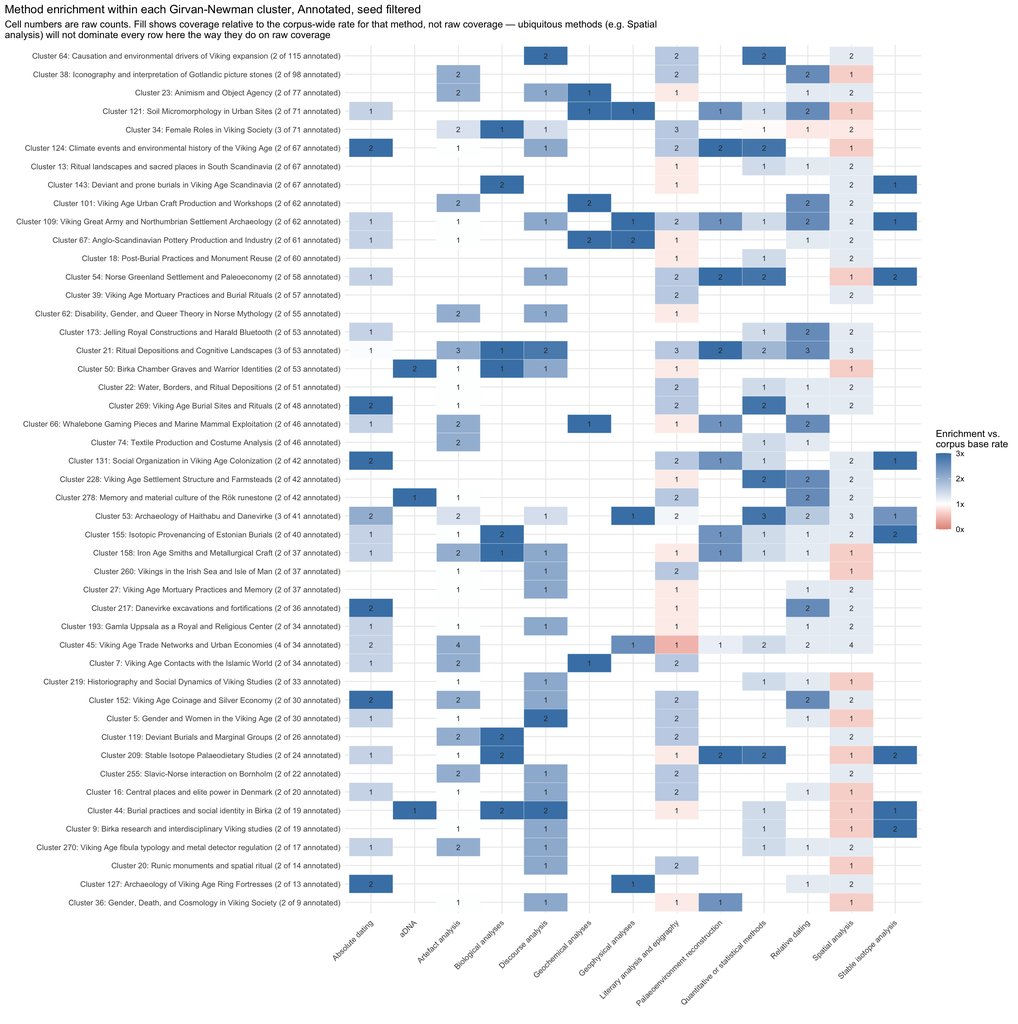

### By source of evidence

Same approach again, applied to source of evidence.

**Annotated**

Works with a cluster assignment and any source coded: 368

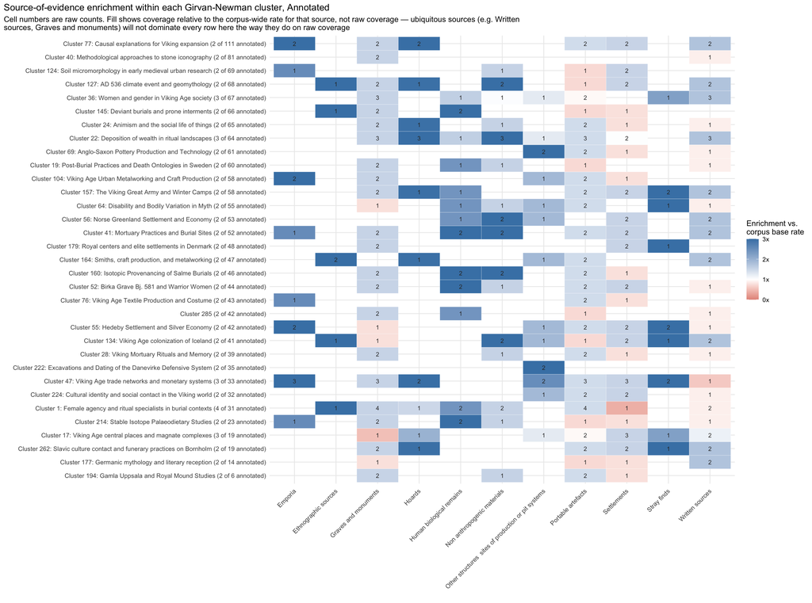

**Annotated, seed filtered**

Works with a cluster assignment and any source coded: 368

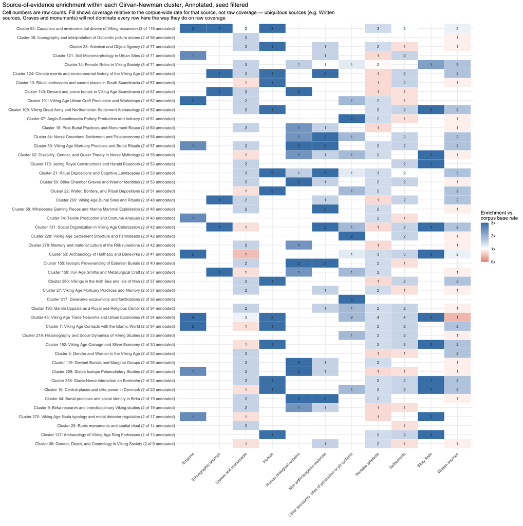

## Cluster signatures: peak count and peak strength

Throughout this section, “cluster” means a Girvan-Newman graph cluster (`community_gn`), not a scholarly or social cluster.

The topic, method, and source enrichment findings above surface individual standout cells one at a time. This section combines them into two directly interpretable numbers per cluster, so the clusters most worth a closer look surface first instead of requiring a manual scan across three separate tables.

For each cluster, two numbers: how many peaks it has, and how strong those peaks are on average. Neither is combined into a single score — peak count times mean enrichment is not a real, interpretable unit, and collapsing two different kinds of signal into one number invites over-reading it. Plotted directly instead: clusters with many peaks AND high average enrichment are worth reading first; a cluster with one very large but isolated peak is a different kind of finding (a strong single signal) than one with several moderate peaks (a broader, possibly more coherent pattern) — the plot keeps that distinction visible rather than flattening it. Whether a cluster’s peak categories actually cohere thematically is a judgment that requires reading them against domain knowledge of this corpus, which this plot does not attempt.

### Peak count against peak strength

**Annotated**

Peaks found (Wilson lower bound exceeds corpus baseline): 101

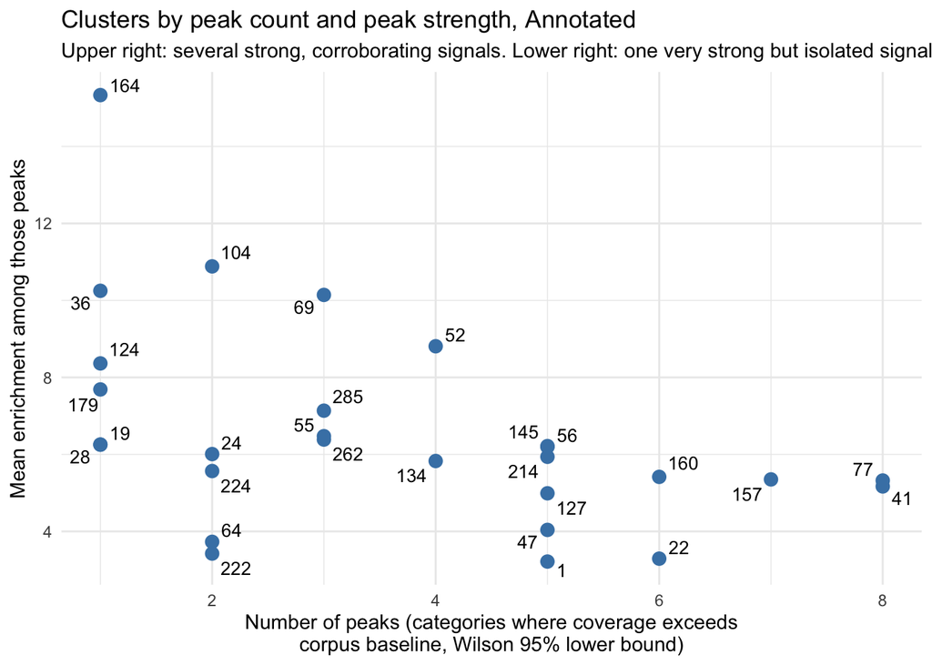

**Annotated, seed filtered**

Peaks found (Wilson lower bound exceeds corpus baseline): 130

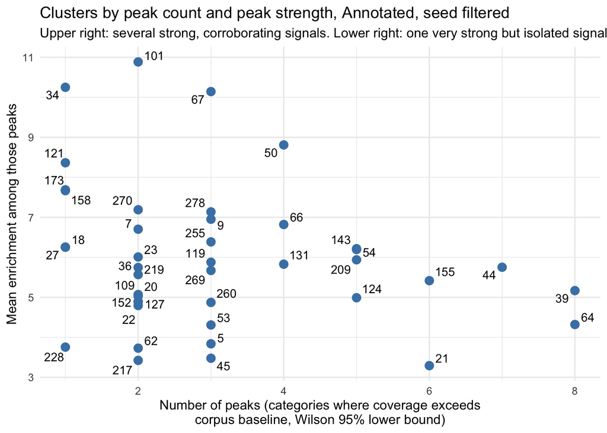

### Peaks behind the clusters with the most peaks

The peak categories behind the clusters with the most peaks, shown directly rather than as a summary number:

**Annotated**

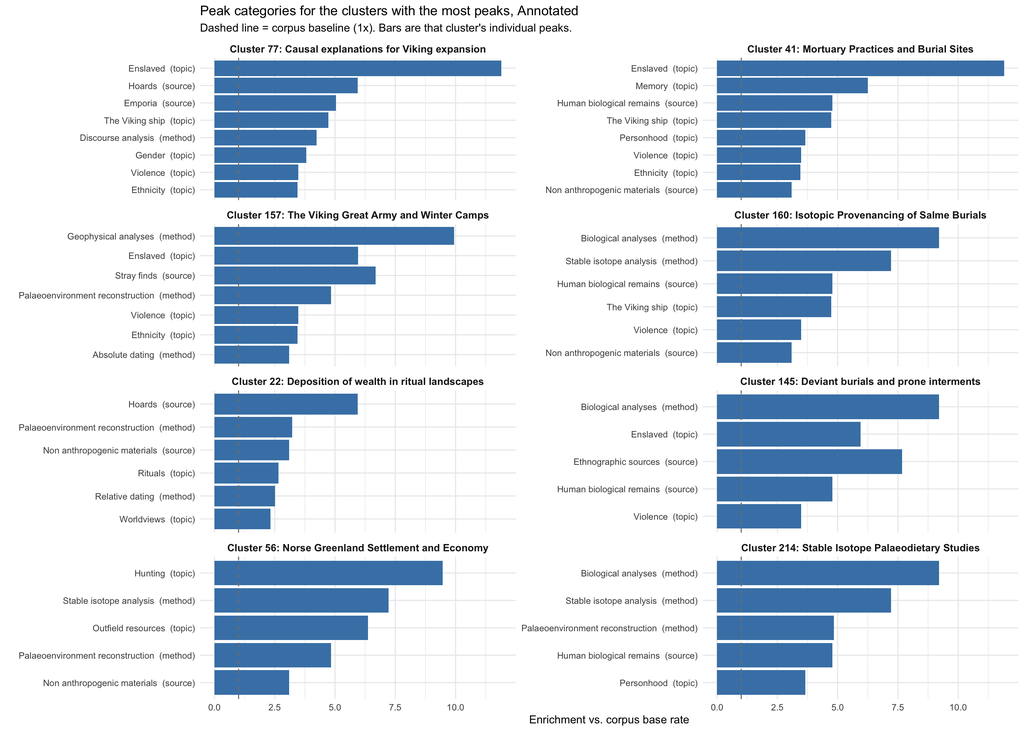

**Annotated, seed filtered**

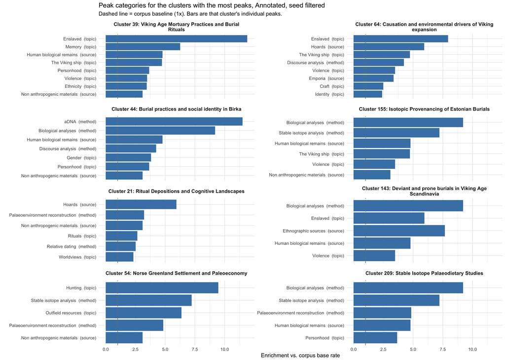

## Groups of clusters vs. topics, methods, and sources of evidence

Part 2 sorts the Girvan-Newman clusters into groups, using a consensus of eight community-detection variants run with five seeds each. This section repeats the comparison above one level up: each group’s annotated works are compared with the annotation of the whole corpus. Enrichment, peaks and heatmaps work as described above, with a group in place of a cluster. In Annotated there are 18 groups, of which 9 hold at least 10 annotated works (between 12 and 59 each); 9 of those 9 carry at least one peak (70 peaks in all), and the strongest is Stable isotope analysis in Group 7 at 5.9x. In Annotated, seed filtered there are 13 groups, of which 8 hold at least 10 annotated works (between 17 and 61 each); 8 of those 8 carry at least one peak (64 peaks in all), and the strongest is Outfield resources in Group 8 at 5.1x. Groups with fewer than 10 annotated works are listed in the first table but left out of the peaks and heatmaps. Each remaining group holds a few dozen annotated works at most, so only large gaps register as peaks. Each is compared on 42 categories, and about one peak per group could arise by chance at this bound. The uncoded majority of each group may tell a different story.

### What each group stands out for

Every group of two or more clusters, with its number of clusters, its papers, the annotated works among them and the categories it carries furthest above the corpus rate.

**Annotated**

| Group | Clusters | Papers | Annotated papers | Peaks | Strongest peaks (enrichment, annotated papers with it of those coded) |
| --- | --- | --- | --- | --- | --- |
| 1. Archaeological Excavation Standards and Stratigraphy | 53 | 1,948 | 59 | 7 | Emporia (3.4x, 40 of 59); Geochemical analyses (3x, 11 of 59); Craft (1.6x, 40 of 59) |
| 2. Runic Inscriptions and Epigraphy | 63 | 1,720 | 52 | 10 | Memory (3.1x, 25 of 52); Personhood (2.3x, 34 of 52); Ethnographic sources (2x, 7 of 51) |
| 3. Political power and ritual landscapes | 50 | 1,565 | 48 | 6 | Geophysical analyses (2.7x, 13 of 48); Stray finds (1.7x, 13 of 48); Absolute dating (1.7x, 26 of 48) |
| 4. Causal explanations for Viking expansion | 59 | 1,468 | 47 | 9 | Ethnicity (2.4x, 33 of 47); Violence (2x, 29 of 47); Diaspora (2x, 46 of 47) |
| 5. Social-ecological systems in medieval North Atlantic | 80 | 1,333 | 30 | 8 | Hunting (3.7x, 12 of 30); Palaeoenvironment reconstruction (2.6x, 16 of 30); Outfield resources (2.5x, 12 of 30) |
| 6. Archaeology and anthropology of childhood | 76 | 1,303 | 52 | 10 | Biological analyses (2.6x, 16 of 52); Enslaved (2.6x, 12 of 52); Gender (2.2x, 32 of 52) |
| 7. Genomic analysis of Viking Age fisheries | 59 | 1,060 | 30 | 9 | Stable isotope analysis (5.9x, 26 of 30); aDNA (4.3x, 6 of 30); Human biological remains (3.6x, 24 of 30) |
| 8. Ethnicity and inter-cultural contact in Sámi-Norse borderlands | 25 | 531 | 14 | 6 | Outfield resources (5.4x, 12 of 14); Hunting (4.6x, 7 of 14); Palaeoenvironment reconstruction (2.8x, 8 of 14) |
| 9. Cross-cultural contact and hybridity in the Baltic region | 11 | 362 | 12 | 5 | Heritage (3.7x, 3 of 12); Hoards (2.8x, 6 of 12); Ethnicity (2x, 7 of 12) |
| 10. Places of Assembly and Legal Sites | 8 | 309 | 7 | not tested | fewer than 10 annotated works |
| 11. Last millennium climate reconstruction methods | 133 | 274 | 2 | not tested | fewer than 10 annotated works |
| 12. Methodological approaches to stone iconography | 64 | 234 | 6 | not tested | fewer than 10 annotated works |
| 13. Archaeology of ship burials and dating | 26 | 161 | 3 | not tested | fewer than 10 annotated works |
| 14. Theoretical and Critical Approaches to Archaeology | 59 | 139 | 1 | not tested | fewer than 10 annotated works |
| 15. Trade and centers in the Eastern Baltic | 3 | 118 | 3 | not tested | fewer than 10 annotated works |
| 16. Urban Origins and Development in Southern Scandinavia | 19 | 99 | 1 | not tested | fewer than 10 annotated works |
| 17. AD 536 climate event and geomythology | 3 | 70 | 2 | not tested | fewer than 10 annotated works |
| 18. Community 482 | 2 | 2 | 0 | not tested | fewer than 10 annotated works |

**Annotated, seed filtered**

| Group | Clusters | Papers | Annotated papers | Peaks | Strongest peaks (enrichment, annotated papers with it of those coded) |
| --- | --- | --- | --- | --- | --- |
| 1. Archaeology of early urbanization in Southern Scandinavia | 52 | 2,096 | 61 | 6 | Geochemical analyses (3.5x, 12 of 61); Emporia (3.4x, 41 of 61); Craft (1.7x, 41 of 61) |
| 2. Archaeology and experimental reconstruction of Viking ships | 51 | 1,894 | 57 | 9 | Memory (2.7x, 25 of 57); Personhood (2.2x, 36 of 57); Hoards (2.1x, 20 of 56) |
| 3. Beowulf and Germanic Literary History | 46 | 1,545 | 46 | 6 | Geophysical analyses (2.8x, 13 of 46); Stray finds (1.8x, 13 of 46); Absolute dating (1.7x, 25 of 46) |
| 4. Causation and environmental drivers of Viking expansion | 67 | 1,387 | 45 | 9 | Ethnicity (2.6x, 33 of 45); Hoards (1.9x, 15 of 45); Violence (1.9x, 26 of 45) |
| 5. Construction of gender and masculinity in Viking Age Scandinavia | 49 | 1,303 | 47 | 10 | Biological analyses (3x, 16 of 47); Enslaved (2.4x, 10 of 47); Gender (2.4x, 31 of 47) |
| 6. Environmental history and climate impacts in medieval Iceland and Greenland | 44 | 1,276 | 29 | 8 | Hunting (3.8x, 12 of 29); Outfield resources (2.6x, 12 of 29); Ethnographic sources (2.4x, 5 of 29) |
| 7. Isotopic analysis for determining migration and diet in prehistory | 44 | 1,201 | 38 | 10 | Stable isotope analysis (4.9x, 27 of 38); aDNA (3.3x, 6 of 38); Human biological remains (2.9x, 24 of 38) |
| 8. Archaeological theory and the Anthropocene perspective | 58 | 698 | 17 | 6 | Outfield resources (5.1x, 14 of 17); Hunting (4.9x, 9 of 17); Ethnographic sources (3.3x, 4 of 17) |
| 9. Assemblies and Political Governance in Early Medieval Europe | 7 | 309 | 7 | not tested | fewer than 10 annotated works |
| 10. Baltic Region Cultural Contacts | 6 | 290 | 7 | not tested | fewer than 10 annotated works |
| 11. Methodologies for reconstructing past millennium climates | 116 | 274 | 2 | not tested | fewer than 10 annotated works |
| 12. Iconography and interpretation of Gotlandic picture stones | 49 | 261 | 7 | not tested | fewer than 10 annotated works |
| 13. Archaeology of Semigallia and Latvia | 3 | 116 | 3 | not tested | fewer than 10 annotated works |

### Groups by topic

**Annotated**

Works with a cluster assignment and any topic coded: 344

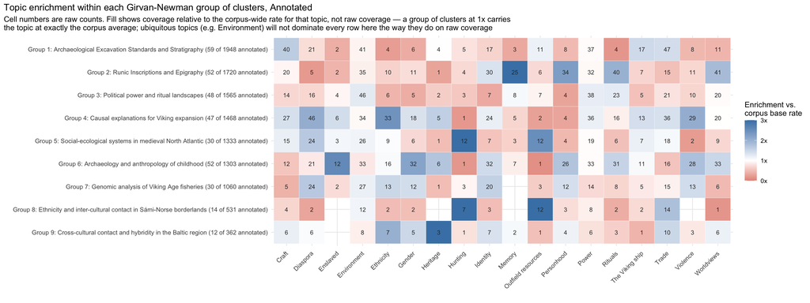

**Annotated, seed filtered**

Works with a cluster assignment and any topic coded: 340

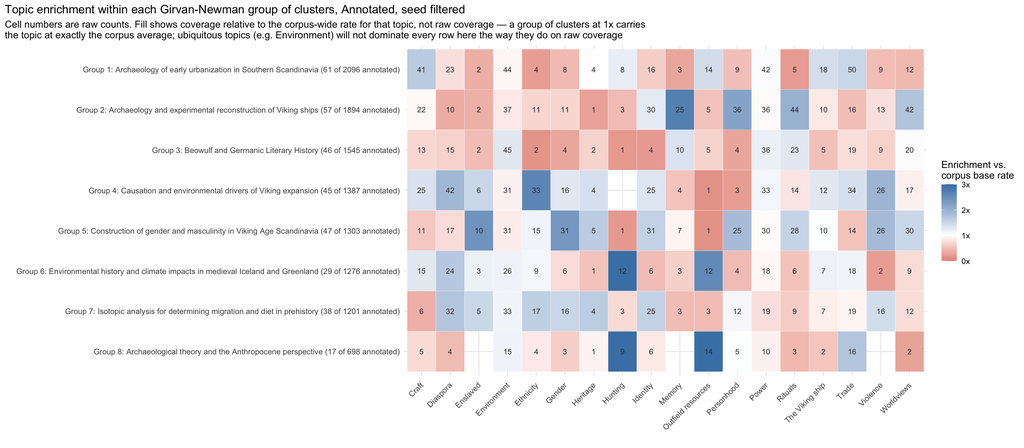

### Groups by method

**Annotated**

Works with a cluster assignment and any method coded: 343

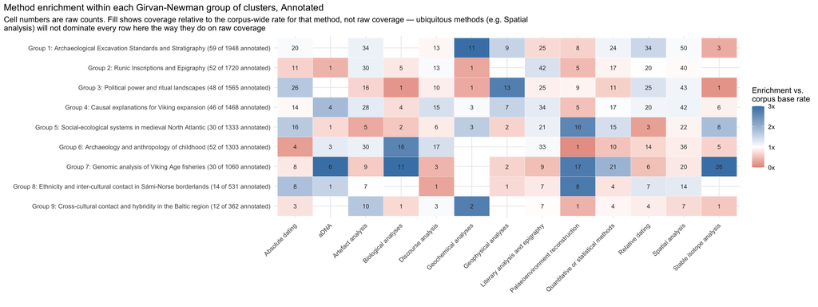

**Annotated, seed filtered**

Works with a cluster assignment and any method coded: 339

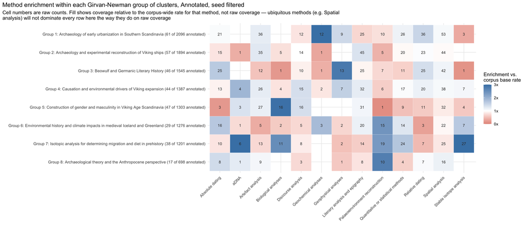

### Groups by source of evidence

**Annotated**

Works with a cluster assignment and any source coded: 343

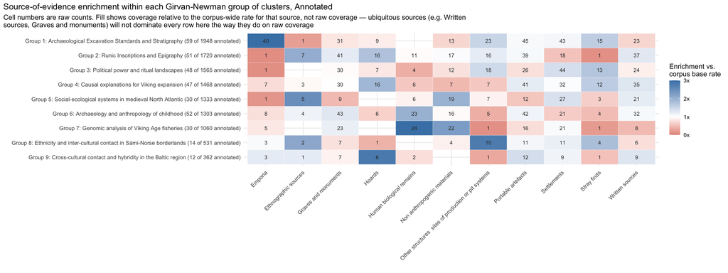

**Annotated, seed filtered**

Works with a cluster assignment and any source coded: 339

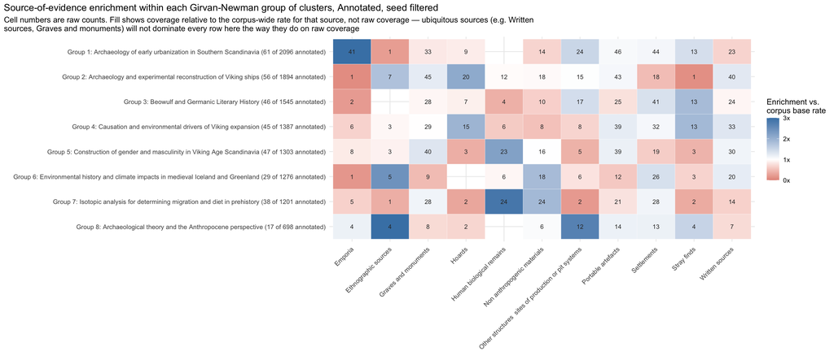